# Homework4

My Own Question: What is the distribution of cocoa percentage in each of the top 3 countries with the most ratings?

Answer: It seems that each country has most of their cocoa percentage coming in the 70%-75% range. I am not too sure on cocoa percentages, but I believe this is the dark chocolate percentage range. This is interesting because I would’ve thought milk chocolate would be more tested. Perhaps this tester likes dark chocolate more, so they tested dark chocolate more often.

Code for My Own Question:

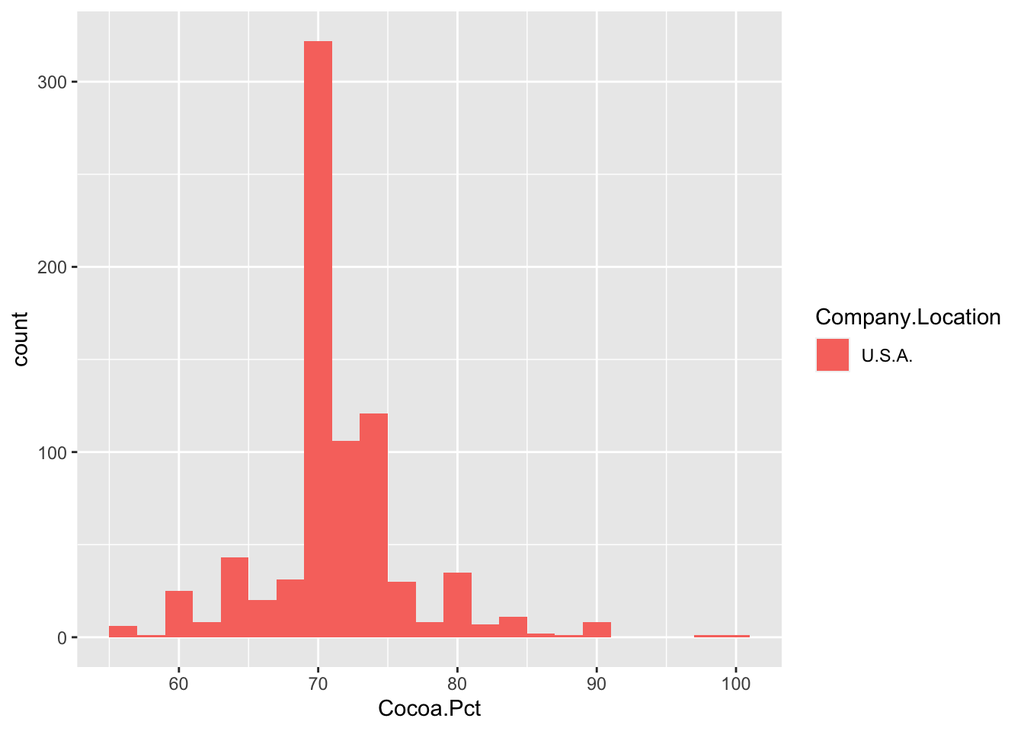

```r
ggplot(usa, aes(x = Cocoa.Pct, fill = Company.Location)) + geom_histogram(binwidth = 2)
```

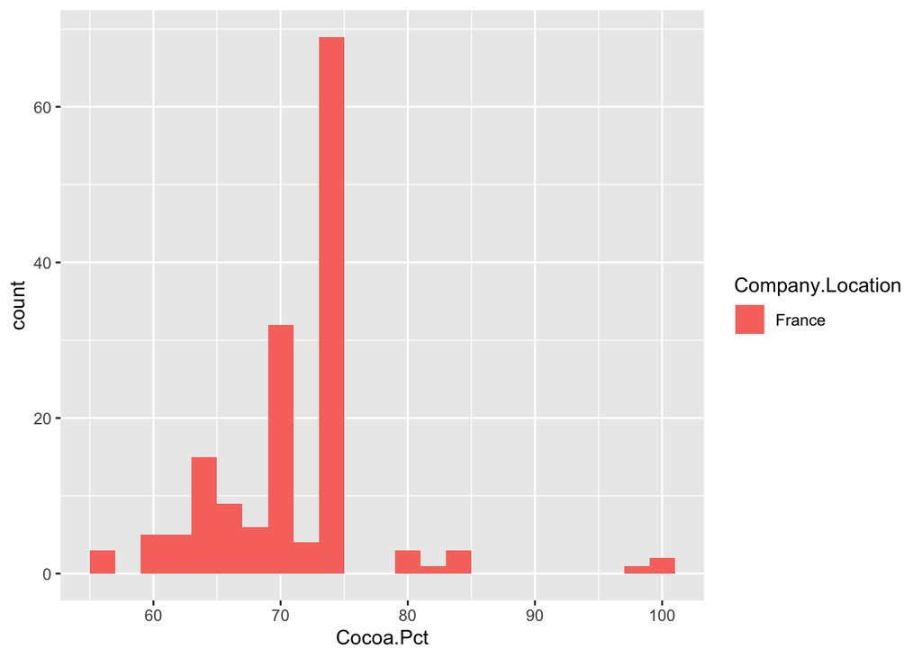

```r
ggplot(france, aes(x = Cocoa.Pct, fill = Company.Location)) + geom_histogram(binwidth = 2)
```

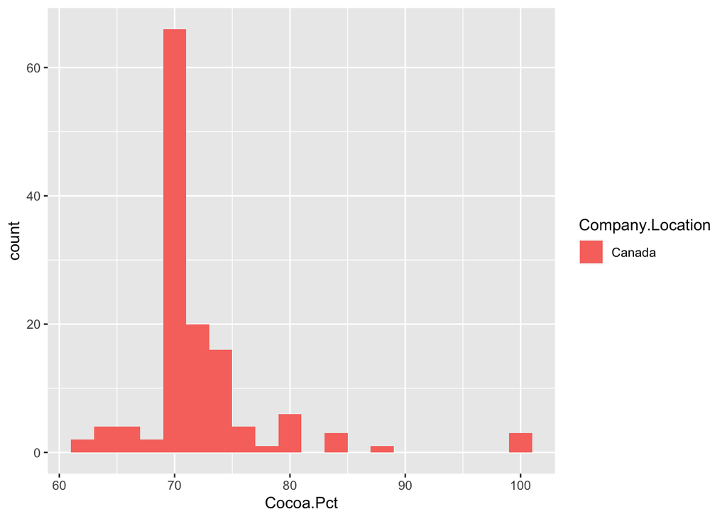

```r
ggplot(canada, aes(x = Cocoa.Pct, fill = Company.Location)) + geom_histogram(binwidth = 2)
```

Github repo: https://github.com/montgomeryinman/HW4

Workflow: The workflow was fairly smooth. I had to look up some documentation of ggplot and dplyr (for the filtered data set), in order to get no errors for my graph, but other than that I seemed to have no problems.